# NYC Green Taxi Sept 2015: Analysis

```r
library(randomForest)
#There are 17 variables, so setting mtry =5
rf.taxi <- randomForest(Tip_perc ~.,
                        data = dataq4[sample(1461113, 14611), ], mtry = 5, importance = TRUE)
importance(rf.taxi)
```

```
##                           %IncMSE IncNodePurity
## lpep_pickup_datetime   19.3539731     25080.585
## Lpep_dropoff_datetime  19.6565044     24506.920
## RateCodeID             15.6729884      3066.041
## Pickup_longitude       28.7498886     54345.967
## Pickup_latitude        27.1294753     42537.744
## Dropoff_longitude      26.1515773     56863.738
## Dropoff_latitude       32.6093725     43563.034
## Passenger_count        -0.4356874      5129.476
## Trip_distance          47.7453248     63098.707
## Fare_amount            31.3164597    121531.952
## Extra                  27.9627775     12338.781
## Tolls_amount            5.7822236      3594.150
## Total_amount           38.3812386    254634.140
## Payment_type          234.6392970   1140785.475
## Trip_type              17.2181797      3290.143
## time.duration          55.3818693     80512.753
## DepTime                13.4255316     21211.353
```

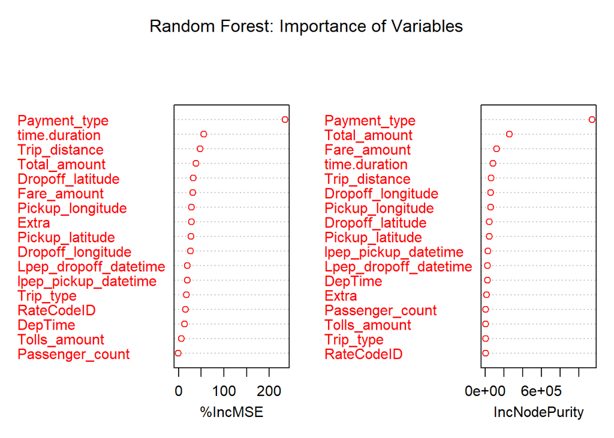

```r
varImpPlot(rf.taxi, col = 'red', main = "Random Forest: Importance of Variables")
```

We built the random forest model on a subset of the original data because of limited computing power. If computing power is not a constraint, predictions can be made using random forest itself. Even though we cannot directly use this model for predictions owing to a possible bias due to limited number of data points, we will use the importance data to build a multiple linear regression model.

```r
dataq4$time.duration <- as.numeric(dataq4$time.duration)

mr <- lm(Tip_perc ~ .-Passenger_count , data = dataq4)
#there is singularity in the data. ::Removing dropoff and pick up times from the data to remove coolinearilty with DepTime

mr_1 <- lm(Tip_perc ~ .-Passenger_count -Lpep_dropoff_datetime -lpep_pickup_datetime , dataq4)

summary(mr_1)
```

```
##
## Call:
## lm(formula = Tip_perc ~ . - Passenger_count - Lpep_dropoff_datetime -
##     lpep_pickup_datetime, data = dataq4)
##
## Residuals:
##      Min       1Q   Median       3Q      Max
## -197.455   -2.073   -0.527    2.452  136.267
##
## Coefficients:
##                     Estimate Std. Error   t value Pr(>|t|)
## (Intercept)        1.350e+01  2.269e-01    59.466  < 2e-16 ***
## RateCodeID2        1.381e+00  1.007e-01    13.714  < 2e-16 ***
## RateCodeID3       -1.369e+00  1.996e-01    -6.857 7.05e-12 ***
## RateCodeID4        4.046e+00  1.834e-01    22.062  < 2e-16 ***
## RateCodeID5        1.083e+00  1.580e-01     6.852 7.28e-12 ***
## RateCodeID6       -2.131e+00  1.278e+00    -1.667   0.0955 .
## Pickup_longitude  -2.033e+00  6.632e-02   -30.655  < 2e-16 ***
## Pickup_latitude   -3.682e+00  1.203e-01   -30.606  < 2e-16 ***
## Dropoff_longitude -1.896e+00  6.546e-02   -28.964  < 2e-16 ***
## Dropoff_latitude  -3.457e+00  1.187e-01   -29.111  < 2e-16 ***
## Trip_distance     -1.386e-01  3.670e-03   -37.778  < 2e-16 ***
## Fare_amount       -3.323e+00  3.796e-03  -875.275  < 2e-16 ***
## Extra             -2.383e+00  1.328e-02  -179.428  < 2e-16 ***
## Tolls_amount      -2.987e+00  6.781e-03  -440.507  < 2e-16 ***
## Total_amount       3.027e+00  3.376e-03   896.427  < 2e-16 ***
## Payment_type2     -1.213e+01  1.202e-02 -1009.443  < 2e-16 ***
## Payment_type3     -1.198e+01  9.799e-02  -122.218  < 2e-16 ***
## Payment_type4     -1.201e+01  9.701e-02  -123.799  < 2e-16 ***
## Payment_type5     -1.176e+01  7.061e-01   -16.655  < 2e-16 ***
## Trip_type2         1.736e+00  1.587e-01    10.940  < 2e-16 ***
## time.duration     -1.995e-05  7.751e-07   -25.743  < 2e-16 ***
## DepTime            8.831e-03  6.829e-04    12.931  < 2e-16 ***
## ---
## Signif. codes:  0 '***' 0.001 '**' 0.01 '*' 0.05 '.' 0.1 ' ' 1
##
## Residual standard error: 5.423 on 1461091 degrees of freedom
## Multiple R-squared:  0.7852, Adjusted R-squared:  0.7852
## F-statistic: 2.544e+05 on 21 and 1461091 DF,  p-value: < 2.2e-16
```

```r
# library(boot)
# mr_1 <- glm(Tip_perc ~ .-Passenger_count -Lpep_dropoff_datetime -lpep_pickup_datetime , data = subset(dataq4,
#                       RateCodeID!=6))
# #This model does not work with RateIDCode = 6. There were 36 datapoints in the original dataset and there are only 18 such points in the present dataset
# cv.error <- cv.glm(subset(dataq4, RateCodeID !=6), mr_1, K=11)
# cv.error$delta
```

Let us look at the residual plot, qq plot of the model

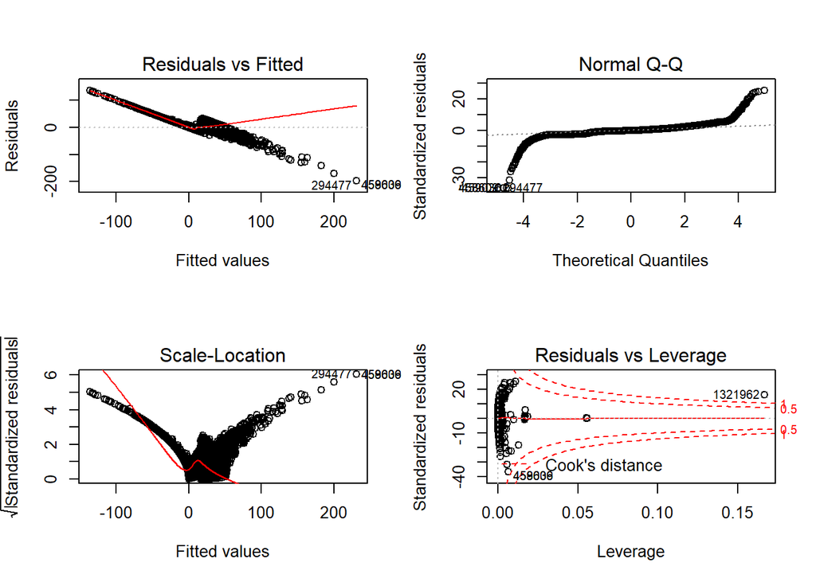

```r
par(mfrow=(c(2,2)))
plot(mr_1)
```

From above, we can infer the model is imperfect. Outliers and leverage points in the data still need to be dealt with. Let us also check collinearity using vif() from library(car)

```r
library(car)
vif(mr_1)
```

```
##                         GVIF Df GVIF^(1/(2*Df))
## RateCodeID         20.775906  5        1.354428
## Pickup_longitude  794.519549  1       28.187223
## Pickup_latitude   795.967309  1       28.212893
## Dropoff_longitude 674.023079  1       25.961954
## Dropoff_latitude  675.367062  1       25.987825
## Trip_distance       6.306008  1        2.511177
## Fare_amount        64.395706  1        8.024694
## Extra               1.168082  1        1.080778
## Tolls_amount        1.776689  1        1.332925
## Total_amount       67.590905  1        8.221369
## Payment_type        1.785653  4        1.075164
## Trip_type          17.960829  1        4.238022
## time.duration       1.010206  1        1.005090
## DepTime             1.072401  1        1.035568
```

Removing collinear terms:

```r
mr_2 <- update(mr_1, ~.-Fare_amount -Dropoff_longitude -Dropoff_latitude -RateCodeID -Trip_type
               -Pickup_longitude -Pickup_latitude)
summary(mr_2)
```

```
##
## Call:
## lm(formula = Tip_perc ~ Trip_distance + Extra + Tolls_amount +
##     Total_amount + Payment_type + time.duration + DepTime, data = dataq4)
##
## Residuals:
##     Min      1Q  Median      3Q     Max
## -106.44   -0.58    0.09    2.67  551.08
##
## Coefficients:
##                 Estimate Std. Error   t value Pr(>|t|)
## (Intercept)    1.785e+01  1.788e-02   998.435  < 2e-16 ***
## Trip_distance -9.141e-01  4.398e-03  -207.840  < 2e-16 ***
## Extra          7.082e-01  1.578e-02    44.875  < 2e-16 ***
## Tolls_amount   1.959e-01  6.881e-03    28.473  < 2e-16 ***
## Total_amount   2.262e-01  1.299e-03   174.147  < 2e-16 ***
## Payment_type2 -1.857e+01  1.182e-02 -1570.314  < 2e-16 ***
## Payment_type3 -1.853e+01  1.210e-01  -153.133  < 2e-16 ***
## Payment_type4 -1.865e+01  1.199e-01  -155.646  < 2e-16 ***
## Payment_type5 -1.802e+01  8.750e-01   -20.599  < 2e-16 ***
## time.duration -4.104e-05  9.600e-07   -42.754  < 2e-16 ***
## DepTime        4.160e-03  8.461e-04     4.916 8.82e-07 ***
## ---
## Signif. codes:  0 '***' 0.001 '**' 0.01 '*' 0.05 '.' 0.1 ' ' 1
##
## Residual standard error: 6.721 on 1461102 degrees of freedom
## Multiple R-squared:  0.6701, Adjusted R-squared:  0.6701
## F-statistic: 2.968e+05 on 10 and 1461102 DF,  p-value: < 2.2e-16
```

```r
library(car)
vif(mr_2)
```

```
##                   GVIF Df GVIF^(1/(2*Df))
## Trip_distance 5.896185  1        2.428206
## Extra         1.074012  1        1.036346
## Tolls_amount  1.191076  1        1.091364
## Total_amount  6.512930  1        2.552044
## Payment_type  1.122536  4        1.014554
## time.duration 1.008896  1        1.004438
## DepTime       1.071750  1        1.035254
```

```r
#colinerilty has been taken care of. VIF values < 10.

#Deleting a few outliers
dataq4_upd <- dataq4[-c(294477, 458606, 1321962),]

library(lubridate)
dataq4_upd$ArrTime <- hour(dataq4_upd$Lpep_dropoff_datetime)
str(dataq4_upd)
```

```
## 'data.frame':    1461110 obs. of  19 variables:
##  $ lpep_pickup_datetime : POSIXct, format: "2015-09-01 00:01:50" "2015-09-01 00:02:36" ...
##  $ Lpep_dropoff_datetime: POSIXct, format: "2015-09-01 00:04:24" "2015-09-01 00:06:42" ...
##  $ RateCodeID           : Factor w/ 6 levels "1","2","3","4",..: 1 1 1 1 1 1 1 1 1 1 ...
##  $ Pickup_longitude     : num  -73.9 -73.9 -74 -73.9 -73.9 ...
##  $ Pickup_latitude      : num  40.8 40.8 40.7 40.8 40.7 ...
##  $ Dropoff_longitude    : num  -73.9 -73.9 -73.9 -73.9 -73.9 ...
##  $ Dropoff_latitude     : num  40.8 40.8 40.7 40.8 40.8 ...
##  $ Passenger_count      : int  1 1 1 1 1 1 1 1 2 1 ...
##  $ Trip_distance        : num  0.59 0.74 0.61 1.07 1.43 0.9 1.33 0.84 0.8 0.7 ...
##  $ Fare_amount          : num  4 5 5 5.5 6.5 5 6 5.5 5 4 ...
##  $ Extra                : num  0.5 0.5 0.5 0.5 0.5 0.5 0.5 0.5 0.5 0.5 ...
##  $ Tolls_amount         : num  0 0 0 0 0 0 0 0 0 0 ...
##  $ Total_amount         : num  5.8 6.3 6.3 8.16 7.8 6.3 8.76 6.8 6.3 6.36 ...
##  $ Payment_type         : Factor w/ 5 levels "1","2","3","4",..: 1 2 2 1 1 2 1 2 2 1 ...
##  $ Trip_type            : Factor w/ 2 levels "1","2": 1 1 1 1 1 1 1 1 1 1 ...
##  $ time.duration        : num  154 246 246 281 298 199 284 310 231 126 ...
##  $ DepTime              : int  0 0 0 0 0 0 0 0 0 0 ...
##  $ Tip_perc             : num  12.5 0 0 24.7 0 ...
##  $ ArrTime              : int  0 0 0 0 0 0 0 0 0 0 ...
```

```r
mr_3 <- lm(Tip_perc ~ .-Passenger_count -Lpep_dropoff_datetime -lpep_pickup_datetime , dataq4_upd)
mr_4 <- update(mr_3, ~.-Fare_amount
               -Dropoff_longitude -Dropoff_latitude -RateCodeID -Trip_type -Pickup_longitude -Pickup_latitude
               -time.duration)

summary(mr_4)
```

```
##
## Call:
## lm(formula = Tip_perc ~ Trip_distance + Extra + Tolls_amount +
##     Total_amount + Payment_type + DepTime + ArrTime, data = dataq4_upd)
##
## Residuals:
##     Min      1Q  Median      3Q     Max
## -105.44   -0.57    0.11    2.66  551.37
##
## Coefficients:
##                 Estimate Std. Error   t value Pr(>|t|)
## (Intercept)    1.783e+01  1.795e-02   993.621   <2e-16 ***
## Trip_distance -9.146e-01  4.403e-03  -207.715   <2e-16 ***
## Extra          7.094e-01  1.579e-02    44.925   <2e-16 ***
## Tolls_amount   1.998e-01  6.885e-03    29.025   <2e-16 ***
## Total_amount   2.241e-01  1.299e-03   172.506   <2e-16 ***
## Payment_type2 -1.857e+01  1.183e-02 -1570.175   <2e-16 ***
## Payment_type3 -1.852e+01  1.211e-01  -152.898   <2e-16 ***
## Payment_type4 -1.864e+01  1.199e-01  -155.448   <2e-16 ***
## Payment_type5 -1.801e+01  8.756e-01   -20.574   <2e-16 ***
## DepTime        2.927e-05  2.287e-03     0.013   0.9898
## ArrTime        4.467e-03  2.246e-03     1.989   0.0467 *
## ---
## Signif. codes:  0 '***' 0.001 '**' 0.01 '*' 0.05 '.' 0.1 ' ' 1
##
## Residual standard error: 6.725 on 1461099 degrees of freedom
## Multiple R-squared:  0.6697, Adjusted R-squared:  0.6697
## F-statistic: 2.962e+05 on 10 and 1461099 DF,  p-value: < 2.2e-16
```

```r
mr_5 <- update(mr_4, ~.-DepTime -ArrTime)
summary(mr_5)
```

```
##
## Call:
## lm(formula = Tip_perc ~ Trip_distance + Extra + Tolls_amount +
##     Total_amount + Payment_type, data = dataq4_upd)
##
## Residuals:
##     Min      1Q  Median      3Q     Max
## -105.56   -0.56    0.11    2.66  552.10
##
## Coefficients:
##                 Estimate Std. Error  t value Pr(>|t|)
## (Intercept)    17.884732   0.014902  1200.14   <2e-16 ***
## Trip_distance  -0.915850   0.004396  -208.33   <2e-16 ***
## Extra           0.729097   0.015285    47.70   <2e-16 ***
## Tolls_amount    0.199774   0.006885    29.02   <2e-16 ***
## Total_amount    0.224441   0.001298   172.92   <2e-16 ***
## Payment_type2 -18.573017   0.011828 -1570.20   <2e-16 ***
## Payment_type3 -18.521025   0.121101  -152.94   <2e-16 ***
## Payment_type4 -18.644236   0.119926  -155.46   <2e-16 ***
## Payment_type5 -18.012848   0.875566   -20.57   <2e-16 ***
## ---
## Signif. codes:  0 '***' 0.001 '**' 0.01 '*' 0.05 '.' 0.1 ' ' 1
##
## Residual standard error: 6.725 on 1461101 degrees of freedom
## Multiple R-squared:  0.6697, Adjusted R-squared:  0.6697
## F-statistic: 3.703e+05 on 8 and 1461101 DF,  p-value: < 2.2e-16
```

```r
summary(mr_4)
```

```
##
## Call:
## lm(formula = Tip_perc ~ Trip_distance + Extra + Tolls_amount +
##     Total_amount + Payment_type + DepTime + ArrTime, data = dataq4_upd)
##
## Residuals:
##     Min      1Q  Median      3Q     Max
## -105.44   -0.57    0.11    2.66  551.37
##
## Coefficients:
##                 Estimate Std. Error   t value Pr(>|t|)
## (Intercept)    1.783e+01  1.795e-02   993.621   <2e-16 ***
## Trip_distance -9.146e-01  4.403e-03  -207.715   <2e-16 ***
## Extra          7.094e-01  1.579e-02    44.925   <2e-16 ***
## Tolls_amount   1.998e-01  6.885e-03    29.025   <2e-16 ***
## Total_amount   2.241e-01  1.299e-03   172.506   <2e-16 ***
## Payment_type2 -1.857e+01  1.183e-02 -1570.175   <2e-16 ***
## Payment_type3 -1.852e+01  1.211e-01  -152.898   <2e-16 ***
## Payment_type4 -1.864e+01  1.199e-01  -155.448   <2e-16 ***
## Payment_type5 -1.801e+01  8.756e-01   -20.574   <2e-16 ***
## DepTime        2.927e-05  2.287e-03     0.013   0.9898
## ArrTime        4.467e-03  2.246e-03     1.989   0.0467 *
## ---
## Signif. codes:  0 '***' 0.001 '**' 0.01 '*' 0.05 '.' 0.1 ' ' 1
##
## Residual standard error: 6.725 on 1461099 degrees of freedom
## Multiple R-squared:  0.6697, Adjusted R-squared:  0.6697
## F-statistic: 2.962e+05 on 10 and 1461099 DF,  p-value: < 2.2e-16
```

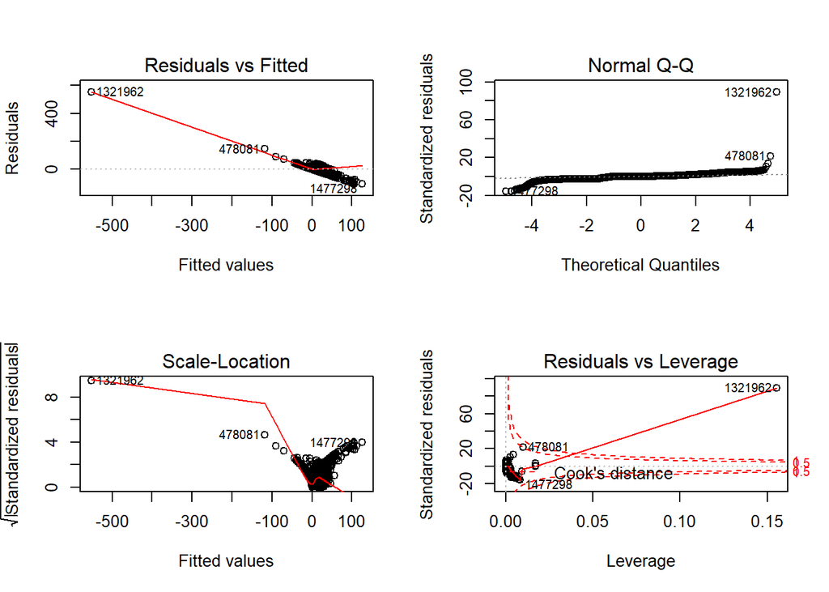

```r
par(mfrow = c(2,2))
plot(mr_5)
```

There are high number of outliers and leverage points in the dataset. Removing too many datapoints will cause the model to overfit the dataset.

**Question 5**

Coordinates of Manhattan are used to create a polygon. ‘sp’ library is used to call point.in.polygon() which determines whether a point is inside a polygon. Here, we use that function to determine whether a particular dropoff/ pickup point is in a particular borough.

Our analysis here is limited only to Manhattan Borough.

```r
###########################################################################################
#Question 5
###########################################################################################
library(sp)

i = 0

Man_px <- c(-74.03, -74.01, -73.98, -73.97, -73.92, -73.93)
Man_py <- c(40.71, 40.70, 40.71, 40.73, 40.80, 40.87)

Brok_px <- c(-73.84, -73.96, -74.05, -73.99)
Brok_py <- c(40.61, 40.74, 40.62, 40.55)

Stni_px <- c(-74.08, -74.19, -74.22, -74.05)
Stni_py <- c(40.64, 40.63, 40.49, 40.60)

Qn_px <-c(-73.75, -73.81, -73.86, -73.94, -73.77)
Qn_py<- c(40.64, 40.60, 40.70, 40.74, 40.79)

Brx_px <- c(-73.77, -73.83, -73.91, -73.92, -73.88)
Brx_py <- c(40.87, 40.80, 40.80, 40.83, 40.90)


dataq5 <- dataq4

library(sp)
dataq5$Borough_drop <- ifelse(point.in.polygon(dataq5$Dropoff_longitude, dataq5$Dropoff_latitude,
                                          Man_px, Man_py) == 1,"Manhattan", "RestofNYC")

dataq5$Borough_pick <- ifelse(point.in.polygon(dataq5$Pickup_longitude, dataq5$Pickup_latitude,
                                               Man_px, Man_py) == 1,"Manhattan", "RestofNYC")

table(dataq5$Borough_drop)
```

```
##
## Manhattan RestofNYC
##    515897    945216
```

```r
table(dataq5$Borough_drop)
```

```
##
## Manhattan RestofNYC
##    515897    945216
```

Following is an interactive map of NYC streets. Hovering over a point will give information about the pick-up and drop-off location. At present, We are considering only Manhattan and RestofNY as our two regions.

```r
set.seed(2)
dataq5_s <- dataq5[sample(1461113, 10000), ]
#Sample of the larger dataset taken for analysis depending on the present computing power.


library(leaflet)

pal <- colorFactor(c("blue","#D22E1E"),levels=c("Manhattan", "RestofNYC"))


maps <-leaflet(dataq5_s)%>%
        addProviderTiles("CartoDB.Positron")
maps %>% setView(-74.00, 40.74, zoom = 10) %>%
          addCircleMarkers(~Pickup_longitude, ~Pickup_latitude, weight = 1, radius = 1, color=~pal(Borough_drop),
                   stroke = TRUE, fillOpacity = 0.1 ,
                   label = ~paste0(" ",Borough_pick," ","to"," ",Borough_drop))
```

[interactive chart not shown]

Clearly, it can be observed that there is a lot more intra-borough traffic in Manhattan. Given more time and computing power, the analysis can be extended to other boroughs of the NYC.

**References:** 1. http://data.library.virginia.edu/working-with-dates-and-time-in-r-using-the-lubridate-package/ 2. http://en.wikipedia.org/wiki/Boro_taxi 3. Book: Introduction to Statistical Learning in R, Gareth James et al 4. Dataset for green cabs for the month of September 2015 is downloaded from http://www.nyc.gov/html/tlc/html/about/trip_record_data.shtml 5. To understand what each entry means in the datset, visit: http://www.nyc.gov/html/tlc/downloads/pdf/data_dictionary_trip_records_green.pdf